# Homework1

David Lawlor

2026-06-09

# connect R studio and github

Did most of the setup in hw0

## 12.2

hw0.

## 12.3

Just put the url into rstudio worked fine

## 12.4

wen’t fine forgot to switch credentials easily fixed

## 12.5

Pushed fine no problems

## 12.6

Checked and saw my changes on the repo on github

## Question 1

install.packages(“mclust”) install.packages(“ggplot2”)

```r
library(mclust)
```

```r
library(ggplot2)
data(banknote)

str(banknote)
```

```
## 'data.frame':    200 obs. of  7 variables:
##  $ Status  : Factor w/ 2 levels "counterfeit",..: 2 2 2 2 2 2 2 2 2 2 ...
##  $ Length  : num  215 215 215 215 215 ...
##  $ Left    : num  131 130 130 130 130 ...
##  $ Right   : num  131 130 130 130 130 ...
##  $ Bottom  : num  9 8.1 8.7 7.5 10.4 9 7.9 7.2 8.2 9.2 ...
##  $ Top     : num  9.7 9.5 9.6 10.4 7.7 10.1 9.6 10.7 11 10 ...
##  $ Diagonal: num  141 142 142 142 142 ...
```

## Question 2

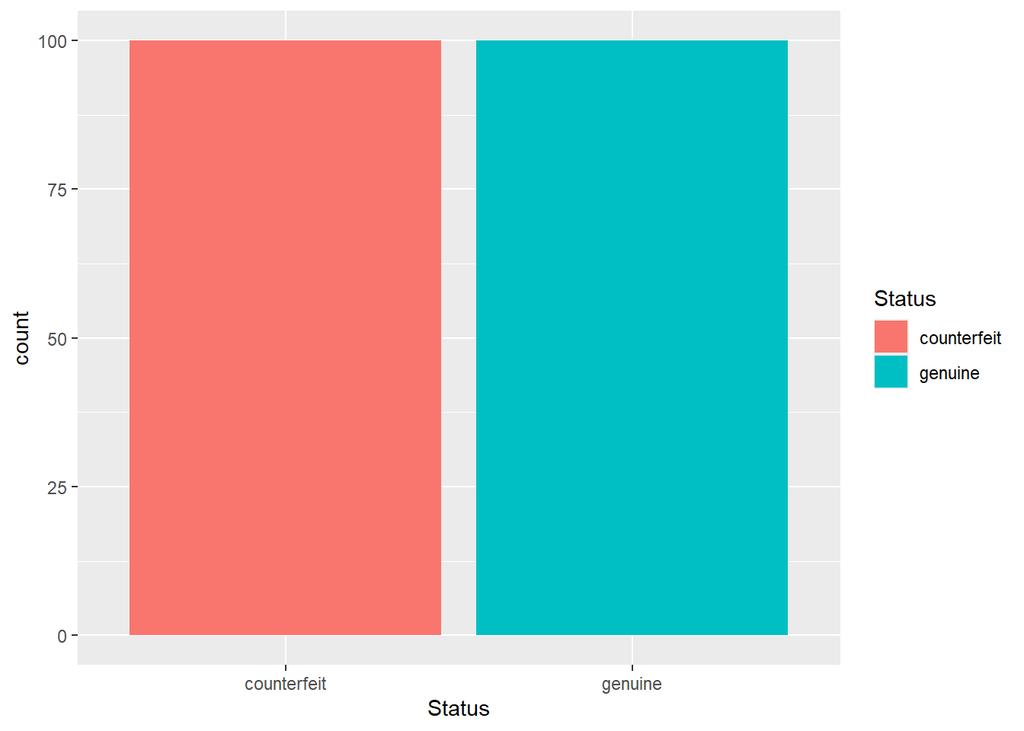

```r
ggplot(banknote, aes(x = Status, fill = Status)) + geom_bar()
```

This is a barchart with Status on the x-axis and fill color. There are exactly 100 genuine and 100 counterfeit banknotes. No anomalies.

## Question 3

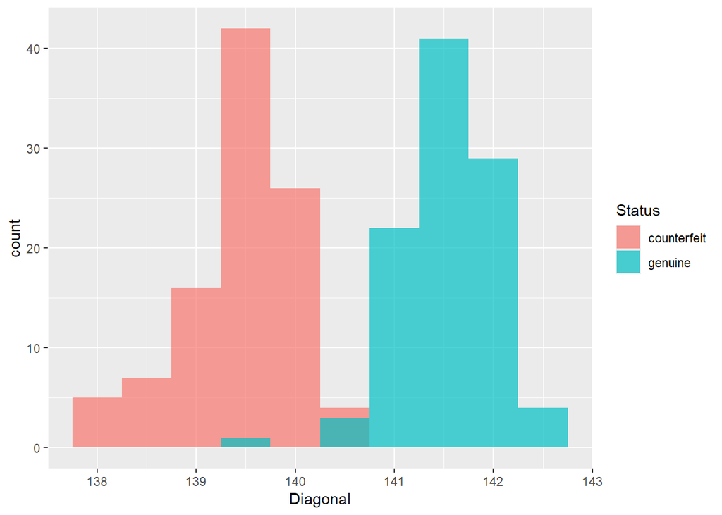

```r
ggplot(banknote, aes(x = Diagonal, fill = Status)) +
geom_histogram(binwidth = 0.5, position = "identity", alpha = 0.7)
```

This is a histogram with Diagonal on the x-axis and Status as fill color. Genuine banknotes have a bigger diagonal than counterfeit ones. There is a small overlap in the middle where the two groups mix.

## 4

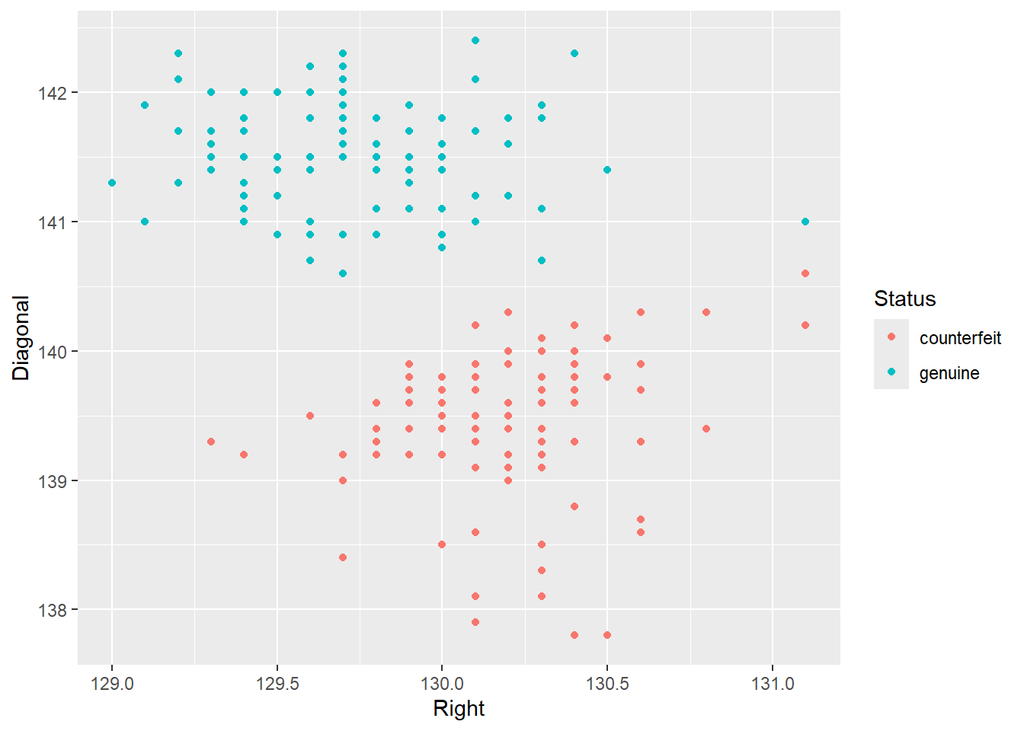

```r
ggplot(banknote, aes(x = Right, y = Diagonal, color = Status)) +
geom_point()
```

This is a scatterplot with Right on the x-axis, Diagonal on the y-axis, and status as the color. The two groups are separate clusters, meaning these two measurements alone can tell apart genuine and counterfeit banknotes. There are a few outliers on both sides, but the two groups still separate.